# HW4

Neha Maddali

10/12/2021

```r
library(ggplot2)
library(tidyverse)
library(dplyr)
#install.packages("nycflights13")
library(nycflights13)
library(knitr)
```

## Question 1

Find if the flight carriers use the same flight number only once in each day. Create a data frame where each row corresponds to a different combination of date, carrier, and flight number, and there should be an additional column once indicating whether the flight number has been used only once (TRUE) or not (FALSE). Finally, print out the first few rows of the records where the once column is FALSE.

```r
dat <- flights %>%
  group_by(year, month, day, carrier, flight) %>%
  summarize(
    count = n(),
    once = (count == 1)
  )
dat
```

```
## # A tibble: 336,752 x 7
## # Groups:   year, month, day, carrier [5,432]
##     year month   day carrier flight count once
##    <int> <int> <int> <chr>    <int> <int> <lgl>
##  1  2013     1     1 9E        3286     1 TRUE
##  2  2013     1     1 9E        3295     1 TRUE
##  3  2013     1     1 9E        3320     1 TRUE
##  4  2013     1     1 9E        3321     1 TRUE
##  5  2013     1     1 9E        3325     1 TRUE
##  6  2013     1     1 9E        3331     1 TRUE
##  7  2013     1     1 9E        3338     1 TRUE
##  8  2013     1     1 9E        3347     1 TRUE
##  9  2013     1     1 9E        3352     1 TRUE
## 10  2013     1     1 9E        3357     1 TRUE
## # ... with 336,742 more rows
```

## Question 2

Add the location of both the origin and destination (i.e. the lat and lon) to flights. Retain only columns for the airport code, airport name, longitude, and latitude. Name the columns in a user-friendly manner.

```r
dat1 <- flights %>%
  select(year, month, day, carrier, flight, origin, dest)
dat2 <- airports %>%
  select(faa, name, lon, lat)

dat1 %>%
  inner_join(airports, by=c("origin"="faa"))
```

```
## # A tibble: 336,776 x 14
##     year month   day carrier flight origin dest  name      lat   lon   alt    tz
##    <int> <int> <int> <chr>    <int> <chr>  <chr> <chr>   <dbl> <dbl> <dbl> <dbl>
##  1  2013     1     1 UA        1545 EWR    IAH   Newark~  40.7 -74.2    18    -5
##  2  2013     1     1 UA        1714 LGA    IAH   La Gua~  40.8 -73.9    22    -5
##  3  2013     1     1 AA        1141 JFK    MIA   John F~  40.6 -73.8    13    -5
##  4  2013     1     1 B6         725 JFK    BQN   John F~  40.6 -73.8    13    -5
##  5  2013     1     1 DL         461 LGA    ATL   La Gua~  40.8 -73.9    22    -5
##  6  2013     1     1 UA        1696 EWR    ORD   Newark~  40.7 -74.2    18    -5
##  7  2013     1     1 B6         507 EWR    FLL   Newark~  40.7 -74.2    18    -5
##  8  2013     1     1 EV        5708 LGA    IAD   La Gua~  40.8 -73.9    22    -5
##  9  2013     1     1 B6          79 JFK    MCO   John F~  40.6 -73.8    13    -5
## 10  2013     1     1 AA         301 LGA    ORD   La Gua~  40.8 -73.9    22    -5
## # ... with 336,766 more rows, and 2 more variables: dst <chr>, tzone <chr>
```

```r
dat3 <- dat1 %>%
  inner_join(dat2 %>%
               select(faa, name_origin=name, lon_origin=lon, lat_origin=lat),
             by=c("origin"="faa")) %>%
  inner_join(dat2 %>%
               select(faa, name_dest=name, lon_dest=lon, lat_dest=lat),
             by=c("dest"="faa"))
dat3
```

```
## # A tibble: 329,174 x 13
##     year month   day carrier flight origin dest  name_origin         lon_origin
##    <int> <int> <int> <chr>    <int> <chr>  <chr> <chr>                    <dbl>
##  1  2013     1     1 UA        1545 EWR    IAH   Newark Liberty Intl      -74.2
##  2  2013     1     1 UA        1714 LGA    IAH   La Guardia               -73.9
##  3  2013     1     1 AA        1141 JFK    MIA   John F Kennedy Intl      -73.8
##  4  2013     1     1 DL         461 LGA    ATL   La Guardia               -73.9
##  5  2013     1     1 UA        1696 EWR    ORD   Newark Liberty Intl      -74.2
##  6  2013     1     1 B6         507 EWR    FLL   Newark Liberty Intl      -74.2
##  7  2013     1     1 EV        5708 LGA    IAD   La Guardia               -73.9
##  8  2013     1     1 B6          79 JFK    MCO   John F Kennedy Intl      -73.8
##  9  2013     1     1 AA         301 LGA    ORD   La Guardia               -73.9
## 10  2013     1     1 B6          49 JFK    PBI   John F Kennedy Intl      -73.8
## # ... with 329,164 more rows, and 4 more variables: lat_origin <dbl>,
## #   name_dest <chr>, lon_dest <dbl>, lat_dest <dbl>
```

## Question 3

Create appropriate numerical and/or graphical summaries to investigate how visibility condition makes it more likely to see a delay. Make sure to also investigate the flight delays with missing visibility values. (Hint: use left_join)

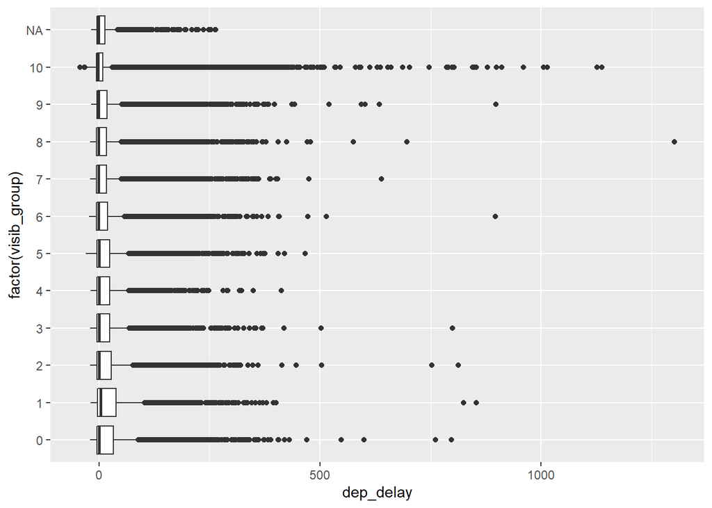

```r
visibPlot <- left_join(flights, weather %>%
                         select(visib, origin, year, month, day, hour),
                       by = c("origin"="origin","year"="year",
                              "month"="month", "hour"="hour", "day"="day")) %>%
  mutate(visib_group = floor(visib)) %>%
  ggplot(aes(factor(visib_group),dep_delay))+geom_boxplot()+coord_flip()
visibPlot
```

## Question 4

Which 5 destination airports have the least severe arrival delay? The severity of delay is defined as the proportion of arriving flights that have no less than 30 minutes arrival delay. To give you a formula, the proportion of delayed flights = the number of delayed flights / the total number of flights. Create a data frame containing the airport name, code, and the severity of delay.

```r
least5 <- flights %>%
  filter(!is.na(arr_delay)) %>%
  mutate(severe = (arr_delay >= 30)) %>%
  group_by(dest) %>%
  summarize(severity=sum(severe)/n()) %>%
  arrange(severity) %>%
  rename("faa"=dest) %>%
  head(5) %>%
  left_join(airports %>% select(name, faa))
least5
```

```
## # A tibble: 5 x 3
##   faa   severity name
##   <chr>    <dbl> <chr>
## 1 LEX     0      "Blue Grass"
## 2 PSP     0      "Palm Springs Intl"
## 3 STT     0.0753  <NA>
## 4 MVY     0.0952 "Martha\\\\'s Vineyard"
## 5 HNL     0.0956 "Honolulu Intl"
```

**My Analysis:** 5 destination airports with the least sever arrival delay are Blue Grass (LEX), Palm Springs Intl (PSP), NA (STT), Martha’s Vineyard (MVY), Honolulu Intl (HNL).

## Question 5

What happened on June 13, 2013? Look at the delay severity by airport on that day, and then use Google to cross-reference with the weather.

```r
juneData <- flights %>%
  filter(!is.na(arr_delay)) %>%
  filter(year == 2013, month == 6, day == 13) %>%
  mutate(severe = (arr_delay >= 30)) %>%
  group_by(dest) %>%
  summarize(severity=sum(severe)/n()) %>%
  rename("faa"=dest) %>%
  left_join(airports %>% select(name, faa))
juneData
```

```
## # A tibble: 86 x 3
##    faa   severity name
##    <chr>    <dbl> <chr>
##  1 ABQ      1     Albuquerque International Sunport
##  2 ACK      0     Nantucket Mem
##  3 ALB      0     Albany Intl
##  4 ATL      0.674 Hartsfield Jackson Atlanta Intl
##  5 AUS      0.571 Austin Bergstrom Intl
##  6 AVL      1     Asheville Regional Airport
##  7 BDL      0     Bradley Intl
##  8 BGR      1     Bangor Intl
##  9 BHM      1     Birmingham Intl
## 10 BNA      0.882 Nashville Intl
## # ... with 76 more rows
```

**My Analysis:** There was a large series of storms (derechos) in the time frame of June 13, 2013